# Binaire logistische regressie met interactie-effecten

Op deze pagina vind je een demonstratie van een statistische techniek aan de hand van een voorbeeld.

Meer informatie over hoe je deze pagina kan gebruiken vind je in deze handleiding.

De analyse gebeurt met behulp van R en RStudio. Een inleiding tot deze software vind je [hier](https://ufora.ugent.be/d2l/le/discovery/view/course/386505).

Het voorbeeld op deze pagina is afkomstig van een studie van Van Nieuwenhove & De Wever (2023). Er zijn kleine wijzigingen aangebracht om didactische redenen. De studie is ook uitgebreider dan wat hier wordt gedemonstreerd.

# 1 Doel

Logistische regressie is een statistische techniek die toelaat om een categorische uitkomstvariabele te modelleren in functie van een reeks predictoren. De predictoren kunnen zowel continu als categorisch zijn. Een eerste voorbeeld van een dergelijk model vind je [elders op Statlas](https://statlas.ugent.be/technieken/Logistische%20regressie/logreg.binair1.html) terug.

Het is mogelijk om interacties tussen predictoren toe te voegen aan een logistisch regressiemodel en om deze te toetsen. De termen “interactie” en “moderatie” worden beide gebruikt. Daarover gaat deze demonstratie.

*Binaire* logistische regressie verwijst naar de specifieke situatie waarin de categorische uitkomstvariabele exact twee waarden (“niveaus”) kan aannemen. Er bestaat ook multinomiale logistische regressie, waarbij de uitkomst meer dan twee waarden kan aannemen.

Logistische regressie maakt deel uit van een familie van statistische technieken die gezamenlijk “Veralgemeend Lineair Model” worden genoemd (in het Engels: “Generalized Linear Model”).

## Het onderzoek van Van Nieuwenhove & De Wever (2023)

In deze demonstratie belichten we een deel van de studie van Van Nieuwenhove & De Wever (2023). Zij proberen te verklaren waarom mensen wel of niet deelnemen aan opleidingen in het volwassenenonderwijs. Hun onderzoek is in belangrijke mate gebaseerd op een courante theorie in de gedragswetenschappen: de theorie van gepland gedrag (afgekort TGG; in het Engels: “theory of planned behavior”). Kort samengevat stelt deze theorie dat gedrag een gevolg is van de intentie om dat gedrag te stellen, waarbij die intentie op zijn beurt het gevolg is van drie grote groepen van oorzaken:

1. Perceptie van controle over gedrag (in het Engels: “Perceived behavioral control”)
2. Perceptie van sociale normen (in het Engels: “Perceived social norms”)
3. Attitudes

Een van de onderzoeksvragen die Van Nieuwenhove & De Wever (2023) zich stelden was of de intentie om wel of niet een opleiding te volgen in het volwassenenonderwijs kan worden verklaard met behulp van deze drie variabelen[^1]. Het is duidelijk dat de intentie om wel of niet deel te nemen aan een opleiding een categorische afhankelijke variabele is met twee niveaus. In een eerste fase was het de bedoeling om die te modelleren in functie van de drie grote variabelen uit de TGG. Om die onderzoeksvraag met die predictoren te bestuderen gebruikten de onderzoekers binaire logistische regressie. Hoe dat werkt vind je in [een andere demonstratie op Statlas](https://statlas.ugent.be/technieken/Logistische%20regressie/logreg.binair1.html).

Van Nieuwenhove & De Wever (2023) bouwen daarna voort op de TGG met als doel om tekortkomingen in de bestaande wetenschappelijke literatuur over volwassenenonderwijs te remediëren. Tot nu toe is er nog geen studie verschenen die uitdrukkelijk personen met verschillende opleidingsniveaus vergelijkt in de context van de TGG en volwassenenonderwijs. Dat is nochtans een interessante piste omdat mensen met een lager opleidingsniveau mogelijk meer psychosociale barrières ervaren, als gevolg van negatievere eerdere ervaringen met onderwijs. De relatie tussen de TGG-predictoren en de beslissing om een opleiding te volgen zou daardoor verschillend kunnen zijn. De auteurs onderzoeken deze hypothese door interactie-effecten (ook moderatie-effecten genoemd) te toetsen. Dat is wat we op **deze pagina** zullen demonstreren.

Van Nieuwenhove & De Wever (2023) gaan in hun studie nog een stap verder en onderzoeken ook de rol van psychosociale barrières bij de intentie om een opleiding te volgen. Dat is het belangrijkste doel van hun artikel (dat kan je al afleiden uit de titel). Dergelijke barrières zijn onderbelicht in de literatuur en dus de moeite waard om te onderzoeken. Meer bepaald vermoeden ze dat eerdere ervaringen met onderwijs een psychosociale barrière zouden kunnen vormen om als volwassene opnieuw een opleiding te volgen. Voor dit alles gebruiken zij een model met mediatie. Dat demonstreren we hier niet.

# 2 Dataset & packages

## De dataset laden

De data die voor de demonstratie worden gebruikt zijn online beschikbaar. Gebruik de volgende code om de data in te laden in RStudio.

```r
barrieres <- read.csv('https://statlas.ugent.be/datasets/barrieres.csv')
```

De dataset `barrieres` bevat de gegevens van 563 respondenten die een vragenlijst invulden. Deze bestond uit 8 vragen.

## Lijst met variabelen

- `intentie` “Ik ben van plan om tijdens de volgende 12 maand deel te nemen aan een vorm van levenslang leren.” De antwoordopties “nee” en “ja” werden gecodeerd als 0 en 1.
- `pcg` Perceptie van controle over het eigen gedrag
- `psn` Perceptie van sociale normen
- `attitudes` Attitudes tegenover het gedrag
- `opl.niveau` Opleiding gehercodeerd in 3 categorieën (1/2/3 = “Laagopgeleid”/“Middenopgeleid”/“Hoogopgeleid”)
- `leeftijd` Een controlevariabele
- `geslacht` Een controlevariabele

Je ziet dat sommige van deze variabelen categorisch zijn. Het is belangrijk dat de categorische predictoren van datatype `factor` zijn. Anders zal R bijvoorbeeld de numerieke codes (`1`, `2` en `3`) van variabele `opl.niveau` interpreteren als echte getallen, wat niet correct is.

```r
barrieres$opl.niveau <- factor(barrieres$opl.niveau)
barrieres$geslacht <- factor(barrieres$geslacht)
```

Om na te gaan dat de omzetting gelukt is kan je het datatype opvragen met de functie `class()`.

```r
class(barrieres$opl.niveau)
```

```
[1] "factor"
```

Merk ook de controlevariabelen `leeftijd` en `geslacht` op. Die voegt men toe om meer zekerheid in te bouwen dat de effecten uit de onderzoeksvraag (waarin men dus het meest geïnteresseerd is) accuraat kunnen worden geschat.

## Packages

Om een logistisch regressiemodel te fitten heb je genoeg aan het basispakket van R (“base R”). Er zijn geen packages nodig. Om effecten te visualiseren zullen we wel gebruik maken van het package `effects`. Je kan het eventueel al installeren. Verderop zullen we uitdrukkelijk vermelden wanneer we dat package gebruiken.

```r
install.packages('effects')
```

# 3 Onderzoeksvraag en aanpak

De hoofdbedoeling is om te achterhalen of er in de data bewijs te vinden is voor interactie-effecten tussen enerzijds het opleidingsniveau en anderzijds de drie predictoren van de TGG. De aanleiding hiervoor was een vermoeden dat de relatie tussen de TGG-predictoren en de intentie om een opleiding te volgen niet hetzelfde is voor mensen met een verschillend opleidingsniveau.

De strategie om op deze onderzoeksvraag een antwoord te bieden bestaat uit een modelvergelijking aan de hand van een “Likelihood Ratio Test” (LRT). Daarbij ga je een model met een reeks predictoren vergelijken met een ander model dat dezelfde predictoren bevat plus een aantal andere predictoren (en/of effecten). We spreken van “geneste modellen”.

In dit voorbeeld is er sprake van een logistische regressiemodel met vijf predictoren. In een diagram ziet dit model er als volgt uit (klik op de afbeelding om te vergroten):

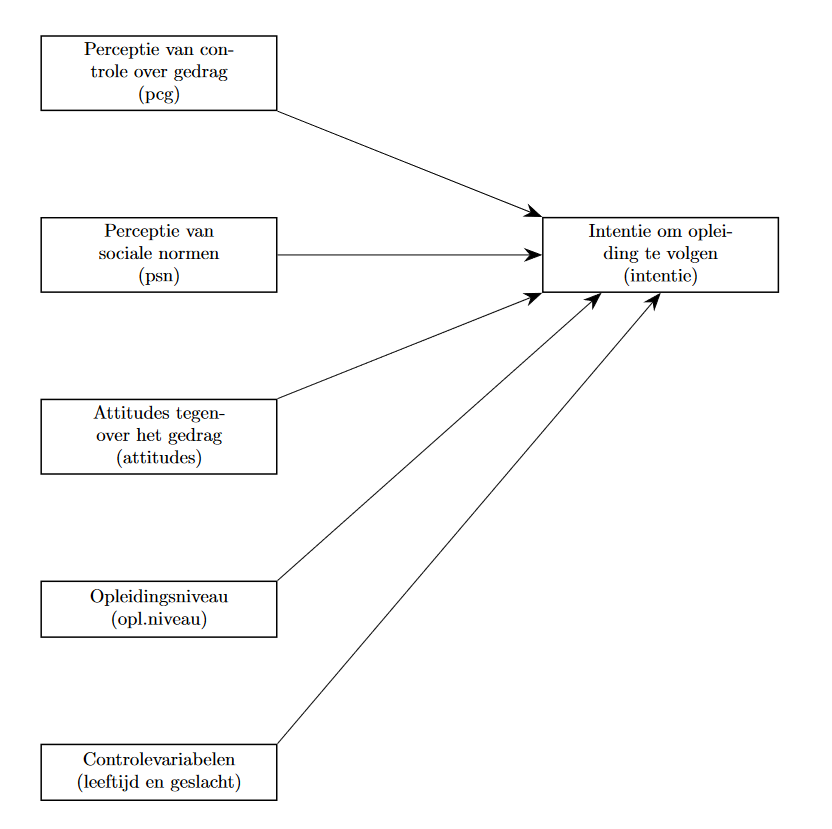

Dit model is genest in een ander model dat dezelfde vijf predictoren bevat, maar daarnaast ook drie interactie-effecten. Deze zijn in het onderstaande diagram aangeduid als rode pijlen. Dit tweede model noemt men “complexer” dan het eerste model.

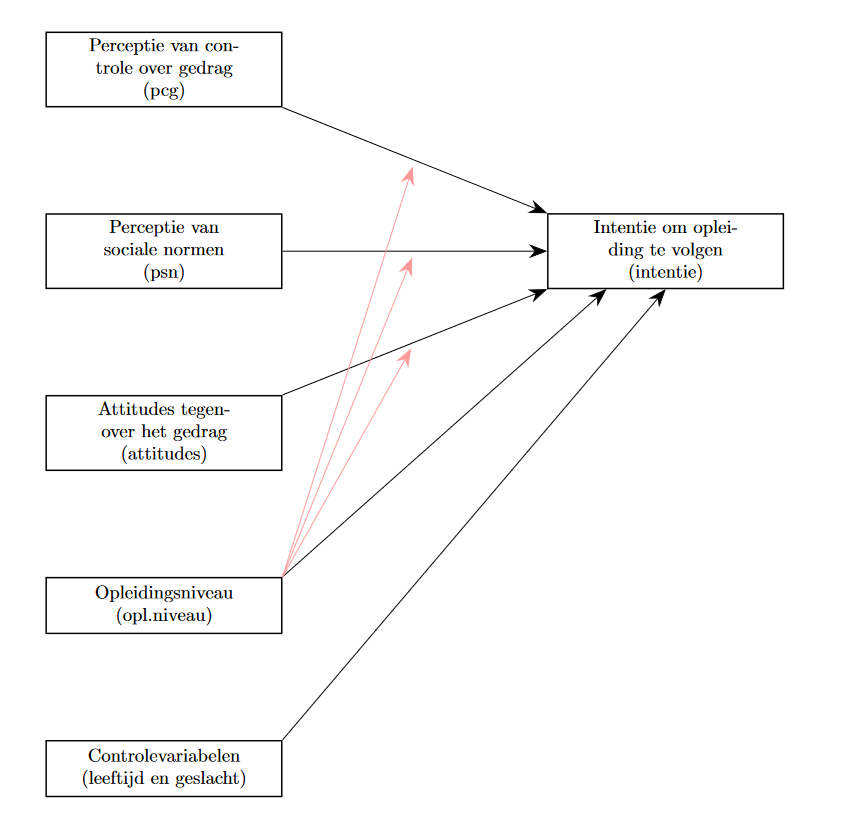

De regressievergelijking van dit laatste model ziet er als volgt uit.

$$\begin{align*}
log\left(\frac{\pi}{1-\pi}\right) = & \beta_0 + \beta_1 \: \times
pcg + \beta_2 \: \times psn + \beta_3 \: \times attitudes \\
& + \beta_4 \: \times opl.niveau2 + \beta_5 \: \times opl.niveau3 \\
& + \beta_6 \: \times leeftijd + \beta_7 \: \times geslacht1 \\
& + \beta_8 \: \times pcg \times opl.niveau2 + \beta_9 \: \times pcg
\times opl.niveau3 \\
& + \beta_{10} \: \times psn \times opl.niveau2 + \beta_{11} \:
\times psn \times opl.niveau3 \\
& + \beta_{12} \: \times attitudes \times opl.niveau2 + \beta_{13}
\times attitudes \times opl.niveau3
\end{align*}$$

$\pi$ staat daarbij voor de kans op de intentie om een opleiding te volgen. $\frac{\pi}{1-\pi}$ is de odds op de intentie om een opleiding te volgen. De logaritme van de odds wordt ook de logit genoemd.

De modelvergelijking is een hypothesetoets. De nulhypothese bij deze toets luidt dat de twee geneste modellen niet van elkaar verschillen. In dat geval is geen enkel van de interactie-effecten aanwezig. De alternatieve hypothese luidt dat de twee geneste modellen wel van elkaar verschillen. Dan is er ten minste één interactie-effect.

Het is zo goed als zeker dat de modellen minstens een beetje van elkaar zullen verschillen in jouw steekproef. Met de modelvergelijking ga je na of het geloofwaardig is dat deze verschillen aan toeval te wijten zijn.

Terzijde, in dit voorbeeld gebruiken we modelvergelijking om drie verschillende interactie-effecten ineens te toetsen, maar dezelfde methode is even goed bruikbaar om bijvoorbeeld één interactie-effect te toetsen.

# 4 Visuele exploratie

Je kan meteen een eerste indicatie krijgen van het antwoord op de onderzoeksvraag door enkele eenvoudige plots aan te maken. Hier is de onderzoeksvraag of het effect van `pcg`, `psn` en/of `attitudes` op `intentie` verschillend is voor verschillende waarden van `opl.niveau`.

Met de functie `levels()` kan je de waarden van `opl.niveau` oproepen. De bedoeling is dus om het effect van de drie predictoren te visualiseren, eerst voor `opl.niveau` gelijk aan `1`, dan voor `opl.niveau` gelijk aan `2` en ten slotte voor `opl.niveau` gelijk aan `3`.

Om uit `barrieres` enkel de observaties te selecteren waar `opl.niveau` gelijk is aan `1`, gebruik je de volgende conditie.

```r
opl.laag <- barrieres$opl.niveau == '1' # let op het dubbele gelijkheidsteken!
```

Met de vector `opl.laag` kan je nu uit `barrieres` de rijen halen die aan deze conditie voldoen.

```r
barrieres[opl.laag,]
```

Dit is een “nieuw” dataframe dat je kan gebruiken als dataset in de functie `boxplot()`.

Het argument `horizontal=TRUE` doet de horizontale en de verticale as van plaats wisselen. Dat is niet echt nodig, maar het zorgt ervoor dat de predictor op de horizontale as komt en de uitkomst op de verticale as, zoals je waarschijnlijk gewoon bent.

Het argument `ylim` legt de minimum- en maximumwaarde op de horizontale as vast. Als je dit niet specifieert bestaat het risico dat sommige plots bijvoorbeeld maar van 2 tot 6 gaan, omdat er geen extreme waarden in de dataset aanwezig zijn. Plots met verschillende assen zouden moeilijker op het zicht te vergelijken zijn, dus dat wil je liever vermijden.

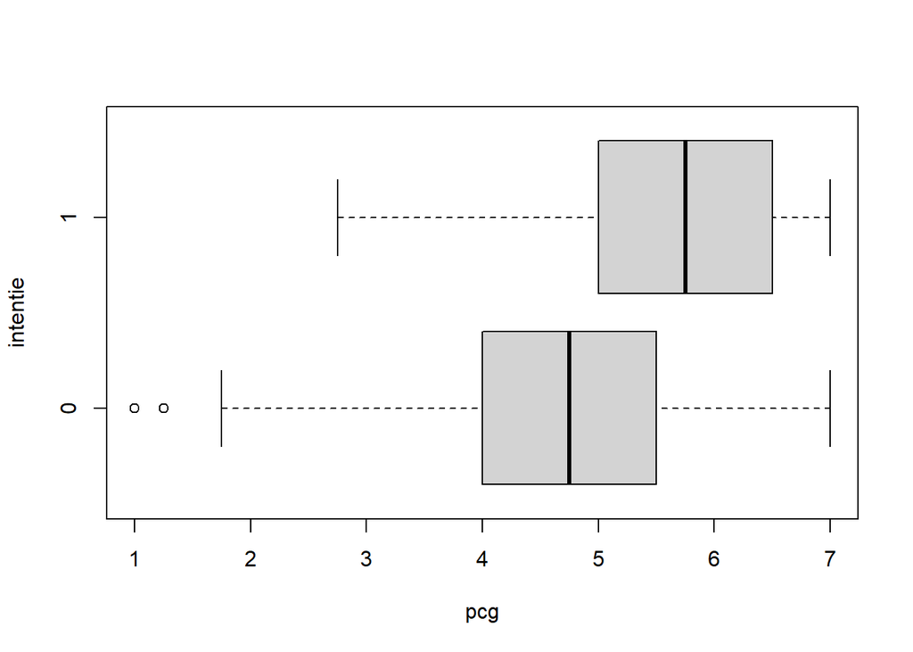

```r
boxplot(pcg ~ intentie,
        data=barrieres[opl.laag,],
        horizontal=TRUE,
        ylim=c(1,7)
        )
```

Uit deze plot kan je afleiden dat bij lagere waarden van `pcg` de intentie vooral gelijk is aan `0` en bij hogere waarden zie je dat de intentie eerder gelijk is aan `1`.

Die eerste plot leert je nog niets over de onderzoeksvraag. Daarvoor moet je het effect van `pcg` bij `opl.niveau` gelijk aan `1` vergelijken met het effect bij `opl.niveau` gelijk aan `2` en `3`. Je hebt dus ook plots nodig voor die condities. Daarna moet je dit allemaal nog eens herhalen voor de predictoren `psn` en `attitudes`! Je hebt dus in totaal 3 $\times$ 3 $=$ 9 plots nodig: er zijn immers drie predictoren die elk (zouden) interageren met `opl.niveau`, dat drie niveaus heeft. De code voor elk van die plots is heel gelijkaardig. Klik op de link om de [code voor alle plots](https://statlas.ugent.be/technieken/Logistische%20regressie/logreg.binair2.9boxplots.R) te zien.

Je ziet de 9 plots hieronder.

De vraag die je hier visueel probeert te beantwoorden is deze: is het effect van `pcg`, `psn` en/of `attitudes` verschillend bij verschillende waarden van `opl.niveau`? Visueel verkennen van het antwoord houdt in dat je nagaat of er in minstens één kolom verschillende effecten te zien zijn tussen de drie plots in die kolom.

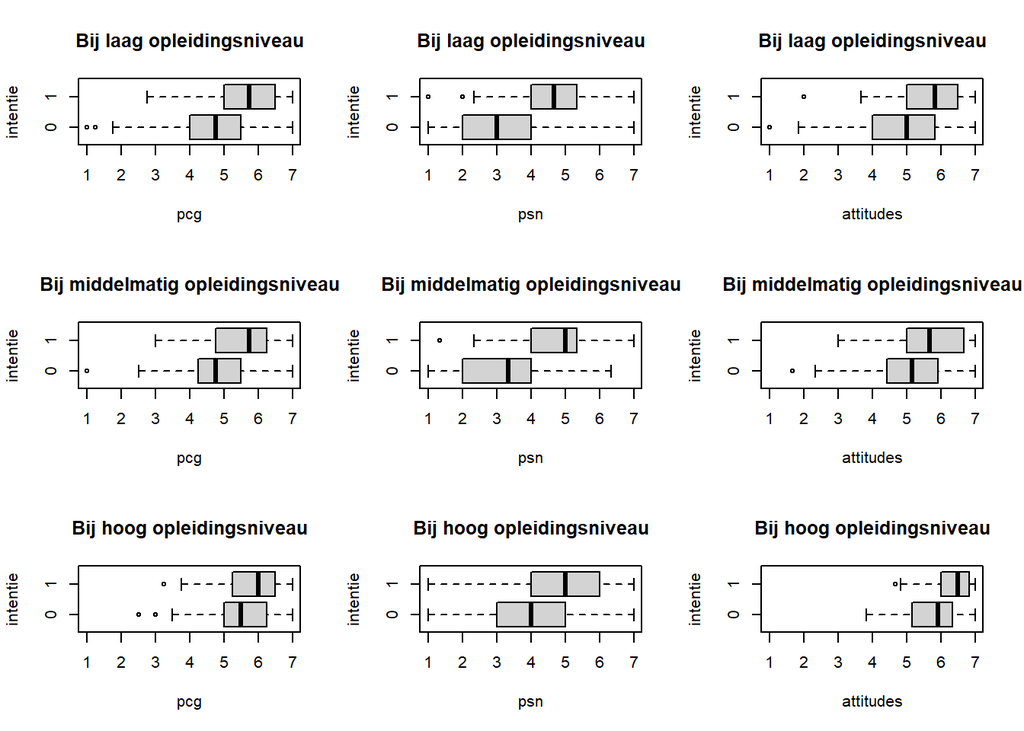

Het antwoord is niet 100% duidelijk. Er zijn misschien wel kleine verschillen, maar zou dit niet aan toeval te wijten kunnen zijn? Het ziet eruit als een twijfelgeval. Meer duidelijkheid zal je hier pas krijgen door een formele significantietoets uit te voeren.

# 5 Modelspecificatie in R

Om de onderzoeksvraag te beoordelen ga je dus twee geneste modellen vergelijken. Daarvoor zal je in R elk model specifiëren, fitten en opslaan in een object. In een volgende stap zal je de modellen vergelijken met behulp van de functie `anova()`.

Eerst het minder complexe model, zonder interacties. Je vertelt erbij uit welk dataframe de gegevens moeten komen (argument `data`) en welk soort analyse je wil uitvoeren (argument `family`). Dat laatste is nodig omdat `glm` ook andere soorten analyses dan logistische regressie aankan. Je kiest voor `link = "logit"` omdat je een logaritme van de odds wil modelleren.

```r
formula.mdl <- 'intentie ~ pcg + psn + attitudes + leeftijd + opl.niveau + leeftijd + geslacht'
mdl <- glm(formula = formula.mdl, data = barrieres, family = binomial(link = 'logit'))
```

Je ziet dat hier in twee stappen wordt gewerkt. Dit is enkel voor de leesbaarheid van de code.

Vervolgens specifieer en fit je het complexere model.

```r
formula.mdl.interactie <- 'intentie ~ pcg*opl.niveau + psn*opl.niveau + attitudes*opl.niveau + leeftijd + geslacht'
```

Je gebruikt de asterisk `*` om interactie-effecten te coderen. Merk op dat alle variabelen die in een interactie-effect betrokken zijn, automatisch ook als hoofdeffect aan het model worden toegevoegd wanneer je `*` gebruikt. Dat is een goede zaak: zonder die hoofdeffecten in het model loop je het risico dat je schattingen van de interactie-effecten fout zijn.

De modelspecificatie kan ook wat korter. Zo hoef je `opl.niveau` geen drie keer te schrijven.

```r
formula.mdl.interactie <- 'intentie ~ (pcg + psn + attitudes)*opl.niveau + leeftijd + geslacht'
```

Het model fitten doe je opnieuw met `glm()`.

```r
mdl.interactie <- glm(formula = formula.mdl.interactie, data = barrieres, family = binomial(link = 'logit'))
```

# 6 Modelvergelijking

Wanneer de modellen eenmaal gefit zijn kan je overgaan tot de modelvergelijking aan de hand van een “likelihood ratio test” (LRT). Dat is een hypothesetoets:

- De nulhypothese stelt dat beide modellen niet van elkaar verschillen (in technische termen: er is geen verschil in “deviance”).
- De alternatieve hypothese stelt dat het complexere model beter is (er is wel een verschil in “deviance”).

```r
anova(mdl, mdl.interactie, test='LRT')
```

```
Analysis of Deviance Table

Model 1: intentie ~ pcg + psn + attitudes + leeftijd + opl.niveau + leeftijd +
    geslacht
Model 2: intentie ~ (pcg + psn + attitudes) * opl.niveau + leeftijd +
    geslacht
  Resid. Df Resid. Dev Df Deviance Pr(>Chi)
1       528     539.48
2       522     533.39  6   6.0956   0.4126
```

Met een p-waarde van 0.4126 kan je de nulhypothese niet verwerpen op het 5% significantieniveau. Er is met andere woorden geen bewijs gevonden voor de bewering dat het model met interactie-effecten beter is.

## Antwoord op de onderzoeksvraag

Dankzij de modelvergelijking heb je meteen een antwoord op de onderzoeksvraag. Er is geen bewijs gevonden voor de vooropgestelde interactie-effecten.

In wat volgt zullen we, louter voor de demonstratie, toch verder werken met het model met interactie-effecten.

# 7 Het model beoordelen

Soms vragen onderzoekers zich af wat de verklarende kracht is van een model in zijn geheel. Om dat te achterhalen in de context van logistische regressie bestaan verschillende technieken die al [elders op Statlas](https://statlas.ugent.be/technieken/Logistische%20regressie/logreg.binair1.html#7_Het_model_beoordelen) aan bod komen. Hier zullen we dit dus niet herhalen.

# 8 Uitgebreide output opvragen

Met de functie `summary()` kan je veel relevante informatie over het model opvragen.

```r
summary(mdl.interactie)
```

```
Call:
glm(formula = formula.mdl.interactie, family = binomial(link = "logit"),
    data = barrieres)

Deviance Residuals:
    Min       1Q   Median       3Q      Max
-2.0341  -0.8073  -0.3302   0.8245   2.5028

Coefficients:
                       Estimate Std. Error z value Pr(>|z|)
(Intercept)           -6.728622   1.361546  -4.942 7.74e-07 ***
pcg                    0.468985   0.212487   2.207 0.027306 *
psn                    0.561931   0.145379   3.865 0.000111 ***
attitudes              0.285993   0.215069   1.330 0.183593
opl.niveau2            0.091777   2.102805   0.044 0.965187
opl.niveau3            1.056392   1.894095   0.558 0.577029
leeftijd              -0.013319   0.008384  -1.589 0.112140
geslacht1              0.058048   0.225221   0.258 0.796610
pcg:opl.niveau2       -0.057955   0.340877  -0.170 0.864997
pcg:opl.niveau3       -0.335319   0.278980  -1.202 0.229385
psn:opl.niveau2        0.193728   0.248474   0.780 0.435585
psn:opl.niveau3       -0.197343   0.186187  -1.060 0.289182
attitudes:opl.niveau2 -0.094408   0.337412  -0.280 0.779632
attitudes:opl.niveau3  0.410814   0.312453   1.315 0.188576
---
Signif. codes:  0 '***' 0.001 '**' 0.01 '*' 0.05 '.' 0.1 ' ' 1

(Dispersion parameter for binomial family taken to be 1)

    Null deviance: 721.95  on 535  degrees of freedom
Residual deviance: 533.39  on 522  degrees of freedom
  (27 observations deleted due to missingness)
AIC: 561.39

Number of Fisher Scoring iterations: 5
```

De parameterschattingen onder `Estimate` zijn interessant omdat die het (eventuele) effect van de predictoren kwantificeren. Die kan je vervolgens gebruiken om ook predicties te genereren. Verderop in deze demonstratie lees je dus …

- hoe je parameterschattingen kan interpreteren (natuurlijk met speciale aandacht voor interactie-effecten)
- hoe je predicties kan genereren aan de hand van diverse waarden voor de predictoren.

# 9 Parameterschattingen interpreteren

In logistische regressie zijn het niet de waarden van de uitkomstvariabele zelf die gemodelleerd worden in functie van predictoren, maar wel de logaritmes van de odds. In dit voorbeeld gaat het om de odds op het hebben van de intentie om een opleiding te volgen. Voor een uitgebreidere uitleg over logaritmes, odds en oddsratio’s, kan je [in deze syllabus](https://statlas.ugent.be/cursussen/MetPsy_cursus20-21.pdf#page=229) terecht.

In de output van `summary(mdl.interactie)` vind je een kolom `Estimate`. Daarin staan parameterschattingen. De interpretatie van deze waarden is niet zo eenvoudig. Wat je wel kan doen is deze kolom met parameterschattingen omrekenen naar odds en oddsratio’s. De kolom maakt deel uit van het object `mdl.interactie` en kan je afzonderlijk selecteren met `mdl.interactie$coef`. Vervolgens geef je dit aan de functie `exp()`.

```r
exp(mdl.interactie$coef)
```

```
          (Intercept)                   pcg                   psn             attitudes           opl.niveau2
           0.00119618            1.59837123            1.75405559            1.33108353            1.09612031
          opl.niveau3              leeftijd             geslacht1       pcg:opl.niveau2       pcg:opl.niveau3
           2.87597587            0.98676949            1.05976550            0.94369246            0.71510997
      psn:opl.niveau2       psn:opl.niveau3 attitudes:opl.niveau2 attitudes:opl.niveau3
           1.21376552            0.82090896            0.90991187            1.50804515
```

Deze odds en oddsratio’s zijn makkelijker te interpreteren.[^2]

Onder `(Intercept)` vind je de geschatte odds voor iemand met waarde 0 voor alle predictoren.

Er zijn ook parameters voor de hoofdeffecten. Bijvoorbeeld, bij `pcg` zie je 1.5984 staan. Dit is een oddsratio, net zoals in een model zonder interactie-effecten, maar let op! De interpretatie is niet helemaal dezelfde als in een model zonder interactie-effecten. In dit model is er namelijk een interactie-effect tussen `pcg` en `opl.niveau`. Dat betekent dat het effect van `pcg` op `intentie` verschillend is naargelang de waarde van `opl.niveau`. Het getal 1.5984 stelt het effect voor van `pcg` op de odds van `intentie`, maar enkel voor het referentieniveau van de categorische variabele `opl.niveau`.

Dus wanneer `opl.niveau` de waarde `1` heeft (wat staat voor “laagopgeleid”), verwachten we voor elke eenheid toename van `pcg` dat de odds op `intentie` veranderen met factor 1.5984. Deze oddsratio is groter dan 1 , dus we verwachten dat de odds op `intentie` groter wordt naarmate `pcg` hoger is.

Wat is dan het effect van `pcg` voor andere niveaus van `opl.niveau`? Bijvoorbeeld het effect van `pcg` voor `opl.niveau` gelijk aan `2` kan je bekomen door 1.5984 te vermenigvuldigen met 0.9437. Het resultaat van deze vermenigvuldiging 1.5084 is ook een oddsratio.

Wanneer `opl.niveau` de waarde `2` heeft, verwachten we voor elke eenheid toename van `pcg` dat de odds op `intentie` veranderen met factor 1.5084. Deze oddsratio is groter dan 1, dus we verwachten dat de odds op `intentie` groter wordt naarmate `pcg` hoger is, maar in mindere mate dan wanneer `opl.niveau` gelijk is aan `1`.

# 10 Visualiseren

Om de geschatte effecten te visualiseren kan je het `effects`-package gebruiken. Dat moet je eenmalig installeren en daarna bij elke R-sessie laden.

```r
install.packages('effects')         # eenmalig
library(effects)                    # bij elke sessie
```

Omdat de onderzoeksvraag gaat over interactie-effecten is het de bedoeling om het effect van bijvoorbeeld `pcg` afzonderlijk te zien voor `opl.niveau` gelijk aan `1`, `2` en `3`. De functie `predictorEffect()` zorgt daar vanzelf voor. Je geeft enkel de predictor in kwestie en het modelobject `mdl.interactie`. De functie “weet” dat `pcg` in je model betrokken is in een interactie met `opl.niveau` en genereert vanzelf een plot voor elk niveau van die variabele.

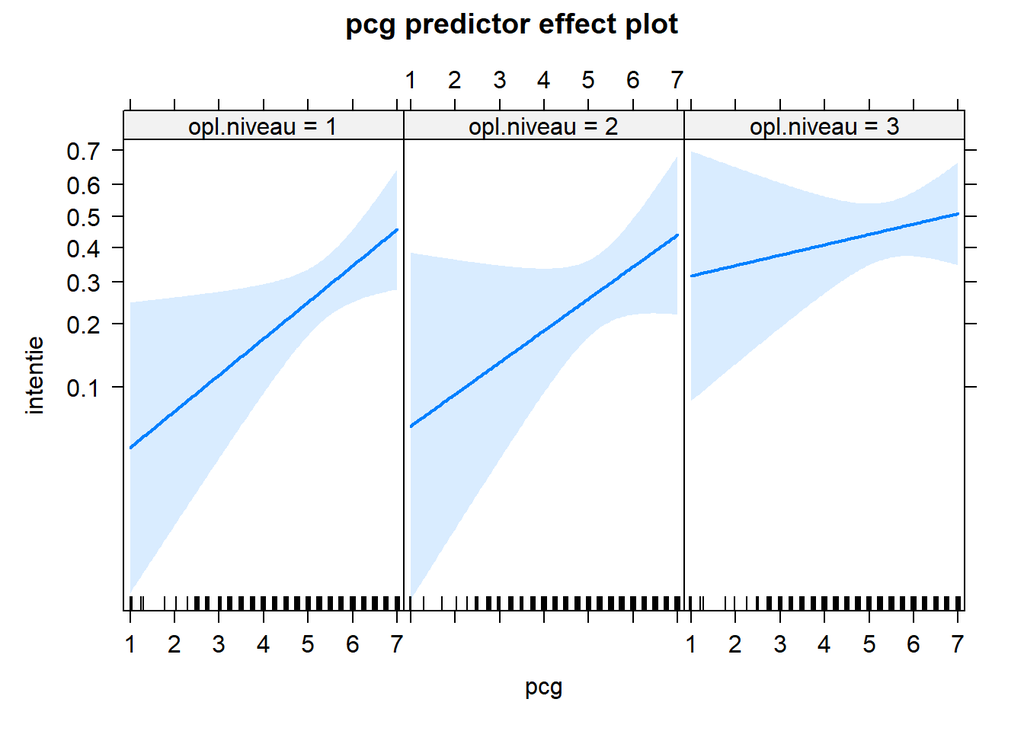

```r
effects.pcg <- predictorEffect('pcg', mdl.interactie)
plot(effects.pcg)
```

Op de horizontale as van elke plot verschijnen de verschillende waarden die de predictor kan aannemen. De verticale as toont de kans (dus niet de log(odds) of de odds!) op `intentie` voor elke waarde van de predictor. Kansen aflezen op de verticale as is niet noodzakelijk interessant. De plot toont immers de lineaire relatie tussen de predictor en de uitkomst `intentie` *voor specifieke vaste waarden van de overige predictoren* (zoals `attitudes` of `leeftijd`). Voor andere waarden van de overige predictoren zal de rechte hoger of lager liggen. Het interessante aan een dergelijke plot is de helling van de rechte. Die vertelt je iets over de relatie tussen de predictor en de uitkomst.

Merk ook op dat de verticale as herschaald is. De streepjes bij 0.1 en 0.2 liggen niet even ver uit elkaar als de streepjes tussen 0.2 en 0.3, enzovoort. Dat komt omdat in een logistisch regressiemodel de kans geen lineaire functie is van de predictoren.

Gelijkaardige plots voor `psn` en `attitudes` bekom je op analoge wijze.

# 11 Predicties

Dankzij de schattingen die we hebben bekomen in de output van `summary(mdl.interactie)` is het nu mogelijk om predicties te berekenen. Voor een persoon met bepaalde waarden voor de predictoren kan je berekenen wat de geschatte waarde is voor de uitkomstvariabele.

## Log-schaal of logit-schaal

In logistische regressie modelleren we niet `intentie` (de uitkomstvariabele) zelf in functie van de predictoren, maar wel de logaritme van de odds op `intentie`. Wanneer je waarden voor de predictoren in de regressievergelijking stopt, dan kom je natuurlijk waarden voor de logaritme van de odds (“logit”) uit, niet voor de uitkomstvariabele zelf. Voor meer uitleg kan je opnieuw terecht [in deze syllabus](https://statlas.ugent.be/cursussen/MetPsy_cursus20-21.pdf#page=229).

Je kan de logaritme van de odds zelf berekenen door waarden voor de predictoren in te vullen in de regressievergelijking.

$$\begin{align*}
log\left(\frac{\pi}{1-\pi}\right) = & \beta_0 \\
& + \beta_1 \: \times pcg \\
& + \beta_2 \: \times psn \\
& + \beta_3 \: \times attitudes \\
& + \beta_4 \: \times opl.niveau2 \\
& + \beta_5 \: \times opl.niveau3 \\
& + \beta_6 \: \times leeftijd \\
& + \beta_7 \: \times geslacht1 \\
& + \beta_8 \: \times pcg \times opl.niveau2 \\
& + \beta_9 \: \times pcg \times opl.niveau3 \\
& + \beta_{10} \: \times psn \times opl.niveau2 \\
& + \beta_{11} \: \times psn \times opl.niveau3 \\
& + \beta_{12} \: \times attitudes \times opl.niveau2 \\
& + \beta_{13} \times attitudes \times opl.niveau3
\end{align*}$$

Je kan dit makkelijk opvragen in R voor alle observaties in je dataset. Gebruik daarvoor de functie `predict()`.

```r
predict(mdl.interactie)
```

```
            1             2             3             4             5             6             7             9
 0.8940863745  0.4627470154  1.3778612262 -0.5339392010 -0.5731288259  0.5491901365  0.8455989981 -1.1423837676
           10            11            12            13            14            15            16            17
-0.5694729302  0.4050374368 -2.6896959687  0.2227711979  1.7860455952  0.1510005526 -2.8692280288  0.9945750516
           18            19            20            21            22            23            24            25
 1.4208966907  1.1960654256  0.6557918895 -1.9310103051 -3.2425849358  0.7451913508  0.9179306588 -0.5968843856
           26            28            29            30            31            32            33            34
-2.3843109905  1.5220177659 -1.6326229974 -2.8674598779  1.6957399752 -0.6600681969  0.6376660915 -1.3396029023
           35            36            37            38            39            40            41            42
 1.2411409168  0.0970410540 -3.2928798367  0.3981637308  1.0046589553  1.5264742581 -0.7901706998 -2.9195135261
           43            44            45            46            47            48            49            50
 1.3273779388 -0.3798045553 -2.7941038091  0.8606917902 -3.4821126684  0.3764287308  1.0570279413  1.6582415444
           51            52            53            54            55            56            57            58
-0.9428208953 -4.2576892501 -0.5874792545 -4.7105759285 -1.7696848096 -1.9889664256  0.2939497292  1.4655772423
           59            60            61            62            63            64            65            66
-0.8286490193 -0.0164879120 -0.7937696662 -1.8361612539  0.3844795950  1.6138200755 -1.4250638168  0.7146781172
           67            68            69            70            71            72            73            74
-0.0110396531 -0.7453001384  0.7025626124 -0.6176474416  1.5604372144  0.3836429373 -1.8780556142 -1.2679739860
           75            76            77            78            79            80            81            82
 0.8882383342  1.1479092331 -1.1174658370 -0.6312541517 -0.8825769486  0.1396256741 -2.5796789857 -2.6330771252
           83            84            85            86            87            88            89            90
-0.4088291253 -0.9304770760 -0.1207463231 -0.2444520110  0.0862213568 -3.2576874090 -3.1213258193 -1.7172518321
           91            92            93            94            95            96            97            98
-1.2340295722 -2.1300719141 -2.0129726220 -2.5971325146 -1.4472272304  0.6565307398 -1.2597069296 -0.9156833298
           99           100           101           102           103           106           107           108
-0.3717385207 -1.7290512867 -0.4742436611 -5.8268447165 -0.7896973679 -1.5623537228  1.1792243438 -0.7035325716
          109           110           111           112           114           115           116           117
 0.0822795339  1.7973473677 -0.3277798810 -2.5493223485 -3.1610612190 -0.7634254008 -1.3221705970  0.8516497714
          118           119           120           121           122           123           124           125
 1.3184657410 -0.9040459474  0.8208693313 -0.9576979342 -0.4653364542 -1.8948879831 -0.3289162536 -0.7342758568
          126           127           128           129           130           131           132           133
-5.3291225508 -3.9144968087 -0.8098888738 -2.1724930873 -2.3712280425 -1.1307032959 -0.9631766858 -2.4688959424
          134           135           136           137           138           139           140           142
-2.3847404130 -3.6107893565  2.0030387100 -0.0035000410 -0.9468717406  0.9197855522 -0.0181876186 -1.2276071984
          143           144           146           147           148           149           150           151
 1.1076421388 -2.3425917188  1.9105008345 -0.5124757669  1.0448179248  1.3871697783  1.3827678278 -0.4763591035
          152           153           154           155           156           157           158           159
-3.1206358641  1.9337868844  0.1640168840 -3.0523996995 -1.6787110690 -3.8630348373 -2.7317002894  0.9666128941
          160           161           162           163           165           166           168           169
 0.5609452539  1.4890474508 -2.7634102135 -1.9750364984 -1.7889109975 -0.2810940030 -2.1890561176  1.7624781496
```

[output cut: 79 more lines]

```
 0.4852453018 -0.6834903323 -1.5992723938 -0.9588152704 -2.3153892559 -2.5295149790  1.3098463333  0.9107699650
          507           508           509           510           511           512           513           514
 1.3775868811 -1.6641746984  0.7232922110 -1.5135646595  0.1068243915  1.5190366486 -1.5405124410 -0.3091638590
          515           516           517           518           519           520           521           522
-2.1302055216  0.8602866776 -0.8120769256 -1.6949674651 -4.2158387611 -3.8799901085 -2.6844892140 -3.3170459998
          523           524           526           527           528           529           530           531
-1.7394192844 -0.8559994984 -1.5168666890  0.9065439669 -2.6020032851 -1.3006507001 -0.5288519833 -3.4022228615
          532           533           534           535           536           537           538           539
-1.6605536368 -2.5283791167 -0.9578140883  0.7637717591  0.8979090192  1.2841780539 -3.6111455265  0.1821164971
          540           541           542           543           544           545           546           547
 1.0044910322 -1.7798993323 -0.9722192452  1.2147370856 -0.9064304484 -2.3249133206 -1.1635179397 -3.5888445168
          548           549           550           551           552           553           554           555
 0.0198702646 -3.0874133461 -1.7630702345 -2.8838505433  0.3264699349 -2.9574010827 -0.0187906290 -3.9587424709
          556           557           558           559           560           561           562           563
-0.1977488118 -2.2811991319 -2.1180314684 -2.9271852842 -1.2855652634 -2.9008613405 -1.7519625289 -0.1092975027
```

Bijvoorbeeld, voor de 54e observatie in de dataset kan je aflezen dat $log\left(\frac{\pi}{1-\pi}\right) = -4.7105759$. Als je dat wil kan je altijd narekenen dat dit inderdaad de juiste geschatte log(odds) is voor een persoon met volgende waarden voor de predictoren:

```
  pcg      psn attitudes opl.niveau leeftijd geslacht
 2.75 1.666667  1.833333          1       55        0
```

De log(odds) is niet zo interessant om te rapporteren. Je rekent predicties op de log(odds)-schaal best om naar odds of naar kansen. Hieronder tonen we hoe je dat kan doen.

## Odds-schaal

Predicties op de odds-schaal kan je bekomen door het getal $e$ te verheffen tot de macht $\beta_0 + \beta_1 \: pcg+ \beta_2 \: psn+ \beta_3 \: attitudes$.

Opnieuw kan je dit laten berekenen voor alle observaties in je dataset. Het commando `predict(model1)` leverde log(odds) op. Om hieruit de odds te berekenen in R gebruik je de functie `exp()`.

```r
log.odds <- predict(mdl.interactie)
exp(log.odds)
```

```
          1           2           3           4           5           6           7           9          10          11
2.445100862 1.588431443 3.966409297 0.586290897 0.563758773 1.731849888 2.329372686 0.319057556 0.565823589 1.499358630
         12          13          14          15          16          17          18          19          20          21
0.067901580 1.249534645 5.965814515 1.162997301 0.056742713 2.703575217 4.140831821 3.307079341 1.926667621 0.145001629
         22          23          24          25          26          28          29          30          31          32
0.039062790 2.106844543 2.504103181 0.550524188 0.092152452 4.581460189 0.195416325 0.056843132 5.450677839 0.516816088
         33          34          35          36          37          38          39          40          41          42
1.892059828 0.261949668 3.459558282 1.101905610 0.037146719 1.489087820 2.730975729 4.601922993 0.453767331 0.053959931
         43          44          45          46          47          48          49          50          51          52
3.771142247 0.683995079 0.061169669 2.364796071 0.030742394 1.457071691 2.877805260 5.250070706 0.389527468 0.014154973
         53          54          55          56          57          58          59          60          61          62
0.555726365 0.008999593 0.170386685 0.136836783 1.341716453 4.330042002 0.436638779 0.983647270 0.452137173 0.159428258
         63          64          65          66          67          68          69          70          71          72
1.468849726 5.021958894 0.240493115 2.043528800 0.989021060 0.474591835 2.018919793 0.539211473 4.760902325 1.467621315
         73          74          75          76          77          78          79          80          81          82
0.152887088 0.281401167 2.430843543 3.151596763 0.327107689 0.531924269 0.413715413 1.149843302 0.075798332 0.071857009
         83          84          85          86          87          88          89          90          91          92
0.664427756 0.394365523 0.886258754 0.783133569 1.090047591 0.038477277 0.044098663 0.179558929 0.291117133 0.118828748
         93          94          95          96          97          98          99         100         101         102
0.133590968 0.074486862 0.235221600 1.928091666 0.283737169 0.400243035 0.689534518 0.177452682 0.622355590 0.002947362
        103         106         107         108         109         110         111         112         114         115
0.453982164 0.209642051 3.251850906 0.494834175 1.085759274 6.033621240 0.720521603 0.078134596 0.042380742 0.466067223
        116         117         118         119         120         121         122         123         124         125
0.266556088 2.343509920 3.737682403 0.404928024 2.272474512 0.383775346 0.627923802 0.150335174 0.719703287 0.479852815
        126         127         128         129         130         131         132         133         134         135
0.004848322 0.019950585 0.444907504 0.113893317 0.093365998 0.322806148 0.381678485 0.084678297 0.092112888 0.027030502
        136         137         138         139         140         142         143         144         146         147
7.411543446 0.996506077 0.387952744 2.508752336 0.981976778 0.292992813 3.027212227 0.096078307 6.756471825 0.599010731
        148         149         150         151         152         153         154         155         156         157
2.842880858 4.003503202 3.985918711 0.621040424 0.044129099 6.915649482 1.178234208 0.047245413 0.186614354 0.021004158
        158         159         160         161         162         163         165         166         168         169
0.065108492 2.629024577 1.752328113 4.432870979 0.063076298 0.138756248 0.167142089 0.754957364 0.112022435 5.826859346
        170         171         172         173         174         175         176         177         178         179
0.161223940 0.033797987 1.693781903 2.542319238 0.142673292 1.063504581 0.181829607 0.628477729 0.570365199 0.322066942
        180         181         182         183         184         185         187         188         189         190
0.710691411 0.549815796 1.641645595 4.046749310 0.219033502 2.384040127 5.638057956 0.293154049 3.665546719 0.551105092
        191         192         193         194         195         196         197         198         199         200
0.827652436 1.241787518 1.810449404 3.344156391 1.065526326 1.559244947 0.657197611 0.583702147 3.462908396 0.490016407
        201         202         203         205         206         207         208         209         210         211
5.003420874 1.894113472 0.370328806 0.158333428 0.812829767 1.248338764 1.037824125 1.537366905 7.502144615 1.409516242
```

[output cut: 53 more lines]

```
1.031957837 0.189441654 2.100596502 3.101820413 0.934089925 0.778962055 0.209049590 0.052279495 1.973506927 4.308454533
        497         498         499         500         501         502         503         504         505         506
1.951862232 0.256777728 1.624573471 0.504851813 0.202043473 0.383346779 0.098727746 0.079697666 3.705604241 2.486236111
        507         508         509         510         511         512         513         514         515         516
3.965321281 0.189346862 2.061207984 0.220123911 1.112738831 4.567822657 0.214271272 0.734060478 0.118812873 2.363838256
        517         518         519         520         521         522         523         524         526         527
0.443935088 0.183605203 0.014759937 0.020651029 0.068256049 0.036259785 0.175622358 0.424858334 0.219398254 2.475751452
        528         529         530         531         532         533         534         535         536         537
0.074124936 0.272354514 0.589281086 0.033299168 0.190033741 0.079788243 0.383730771 2.146356512 2.454465501 3.611698116
        538         539         540         541         542         543         544         545         546         547
0.027020876 1.199753954 2.730517174 0.168655125 0.378242693 3.369408082 0.403963622 0.097791920 0.312385293 0.027630238
        548         549         550         551         552         553         554         555         556         557
1.020068992 0.045619805 0.171517456 0.055919029 1.386066577 0.051953765 0.981384814 0.019087102 0.820575946 0.102161628
        558         559         560         561         562         563
0.120268147 0.053547547 0.276494247 0.054975847 0.173433241 0.896463677
```

Als je dat wil kan je dit opnieuw zelf narekenen voor een bepaalde observatie, bijvoorbeeld nummer 54.

$$\frac{\pi}{1-\pi} = e^{-4.7105759}
\approx 0.0089996$$

## Kansen

Als je eenmaal de odds hebt, dan is het ook mogelijk om de voorspelde kansen $\pi$ te berekenen.

$$\begin{align*}
odds &= \frac{\pi}{1-\pi} \\
& \Updownarrow \\
\pi &= \frac{odds}{1+odds}
\end{align*}$$

In R kan je op basis van die formule een object (hier `kansen`) maken dat voor elke observatie de voorspelde kans bevat.

```r
kansen <- odds/(1+odds)
```

Je kan de kansen ook veel sneller bekomen via de functie `predict()`, door een extra argument mee te geven, of nog korter via de functie `fitted()`.

```r
kansen <- predict(mdl.interactie, type="response")
# of
kansen <- fitted(mdl.interactie)
```

# 12 Referenties

Van Nieuwenhove L. & De Wever B. (2023). Psychosocial barriers to adult learning and the role of prior learning experiences: A comparison based on educational level *Adult Education Quarterly*, doi: 10.1177/07417136231147491

# 13 Voetnoten

[^1]: Elk van deze drie variabelen is berekend door meerdere items uit een enquête te combineren.
[^2]: We interpreteren hier alle schattingen zonder rekening te houden met significantie.